# Cyclistic Bike-Share Analysis

Google Data Analytics Capestone: Case Study

Biswabal Gurung

2022-07-09

## Introduction

Cyclistic bike-share analysis, this case study has been completed as the final capestone project for the Google Data Analytics Professional Certificate. The purpose of this case study is to answer the key business questions of a fictional company, Cyclistic, by following the steps of the data analysis process which has been taught in the course: ask, prepare, process, analyze, share and act.

Cyclistic has been offering bike-share program since 2016.The finance analyst team of “Cyclistic” has found out that annual members are much more profitable than casual riders. The marketing director believes that increasing the number of annual members will be the key to the growth of the company.Rather than targeting new customers the marketing director sees potential of casual riders opting for annual membership by designing marketing strategies aimed at converting casual riders into annual members.

The aim of this report is to analyze the historical bike trip data to identify trends and better understand how annual members and casual riders differ.

## Problem Statement

To understand how do annual members and casual riders use bike-share program differently in order to design marketing strategies aiming to convert Cyclistic casual riders into annual members.

## Data Description

The historical bike trip data has been made available to the public by Motivate International Inc., Chicago under this [licence](https://ride.divvybikes.com/system-data). For the purpose of this case study the previous 12 months (June 2021 - May 2022) of trip data has been downloaded from [here](https://divvy-tripdata.s3.amazonaws.com/index.html), prepared and then analyzed.

The dataset contains trip details and each trip includes:

- Trip id
- Type of bikes (classic, docked or electric)
- Trip start day and time
- Trip end day and time
- Trip start station name, id, latitude and longitude
- Trip end station name, id, latitude and longitude
- Type of customer (casual or member)

## Prepare and Process

All the R code chunks which has been implemented to prepare and process the dataset has been documented below.

```r
# load required libraries

library(tidyverse)
library(lubridate)
library(leaflet)
library(htmlwidgets)
library(htmltools)
```

```r
#load all datasets and merge them in one dataframe

list_of_files <-
  list.files(
    path = "C:/Users/grg2b/Desktop/Google Analytics/Case Study/Cyclistic trip data/csv files",
    pattern = ".csv",
    all.files = TRUE,
    full.names = TRUE
  )

all_trips <- data.frame()

for (f in list_of_files) {
  all_trips <- rbind(all_trips, read_csv(f, col_names = TRUE))
}
```

```r
# check structure of the dataframe
str(all_trips)
```

[output not shown]

```r
# rename some columns
all_trips <- rename(all_trips,
                    bike_type = rideable_type,
                    rider_type = member_casual)
```

```r
# look at the head of data
all_trips %>% head()
```

```
## # A tibble: 6 × 13
##   ride_id     bike_type started_at          ended_at            start_station_n…
##   <chr>       <chr>     <dttm>              <dttm>              <chr>
## 1 99FEC93BA8… electric… 2021-06-13 14:31:28 2021-06-13 14:34:11 <NA>
## 2 06048DCFC8… electric… 2021-06-04 11:18:02 2021-06-04 11:24:19 <NA>
## 3 9598066F68… electric… 2021-06-04 09:49:35 2021-06-04 09:55:34 <NA>
## 4 B03C0FE48C… electric… 2021-06-03 19:56:05 2021-06-03 20:21:55 <NA>
## 5 B9EEA89F8F… electric… 2021-06-04 14:05:51 2021-06-04 14:09:59 <NA>
## 6 62B943CEAA… electric… 2021-06-03 19:32:01 2021-06-03 19:38:46 <NA>
## # … with 8 more variables: start_station_id <chr>, end_station_name <chr>,
## #   end_station_id <chr>, start_lat <dbl>, start_lng <dbl>, end_lat <dbl>,
## #   end_lng <dbl>, rider_type <chr>
```

```r
#sort the dataset by dates
all_trips <- all_trips %>% arrange(started_at)
```

```r
#Checking for duplicate rows
if(length(all_trips$ride_id) != n_distinct(all_trips)) {
  print("Duplicate rows")
}
```

```r
# check number of total observations for each bike_type
table(all_trips$bike_type)
```

```
##
##  classic_bike   docked_bike electric_bike
##       3217737        274447       2368592
```

```r
# check number of total observations for each rider_type
table(all_trips$rider_type)
```

```
##
##  casual  member
## 2559857 3300919
```

```r
# create a column "ride_duration"
all_trips$ride_duration <-
  difftime(all_trips$ended_at, all_trips$started_at, units = "mins")

# extract trip date, hour, day of the month, month, year and day of the week for each trip
all_trips$date <- as.Date(all_trips$started_at)
all_trips$hour <- all_trips$started_at %>% hour()
all_trips$day <- all_trips$date %>% mday()
all_trips$month <-
  all_trips$date %>% month(label = TRUE, abbr = FALSE)
all_trips$year <- all_trips$date %>% year()
all_trips$day_of_week <-
  all_trips$date %>% wday(label = TRUE, abbr = FALSE)
```

```r
# check the structure of modified dataframe
str(all_trips)
```

[output not shown]

```r
# convert bike_type and rider_type as factors
all_trips$bike_type <- as.factor(all_trips$bike_type)
all_trips$rider_type <- as.factor(all_trips$rider_type)
```

```r
# examine summary of dataset
summary(all_trips)
```

[output not shown]

Trips greater than 24 hours are highly unlikely and trips less than 1 minutes are potential false start. So for the purpose of this analysis all the trips greater than 24 hours and less than 1 minutes are excluded. In order to improve our analysis we can do further analysis of outliers and handle them accordingly, but for this task we will continue analysis with ride length greater than or equal to 1 mins and less than 24 hours.

```r
# removing ride length < 1 mins and > 24 hours
all_trips <-
  all_trips %>% filter(ride_duration >= 1 & ride_duration < 60 * 24)
```

```r
# count missing values for each column
all_trips %>% sapply(function(x)
  sum(is.na(x)))
```

```
##            ride_id          bike_type         started_at           ended_at
##                  0                  0                  0                  0
## start_station_name   start_station_id   end_station_name     end_station_id
##             798424             798421             844895             844895
##          start_lat          start_lng            end_lat            end_lng
##                  0                  0               1578               1578
##         rider_type      ride_duration               date               hour
##                  0                  0                  0                  0
##                day              month               year        day_of_week
##                  0                  0                  0                  0
```

Many trips has missing start station name, start station ids, end station name, end station id, end station longitude and latitude. This shouldn’t impact our analysis about ride duration and number of rides among rider types(casual and member), so I will leave as it is now. However, I will consider them to be removed later during analysis if I use those column in my analysis.

## Analyze

This step of data analysis includes generating some insights from the data to identify trends and better understand how Cyclistic’s annual members and casual riders differ.

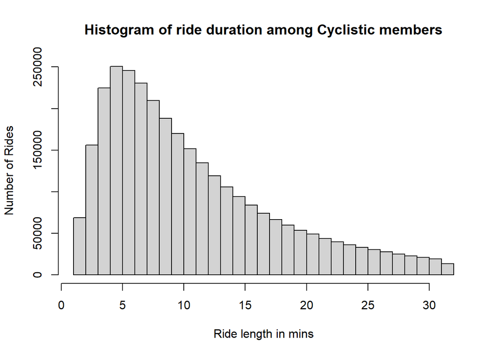

```r
# extract ride duration for only members
member_ride_duration <-
  (all_trips %>% filter(rider_type == "member"))[, "ride_duration"]

# change the data type to numeric
member_ride_duration$ride_duration <-
  member_ride_duration$ride_duration %>% as.numeric()

# don't include outliers
member_ride_duration <-
  member_ride_duration$ride_duration[!member_ride_duration$ride_duration %in% boxplot.stats(member_ride_duration$ride_duration)$out]

# plot histogram to see distribution of ride duration among member
hist(member_ride_duration,
     xlab = 'Ride length in mins',
     ylab = "Number of Rides",
     main = 'Histogram of ride duration among Cyclistic members')
```

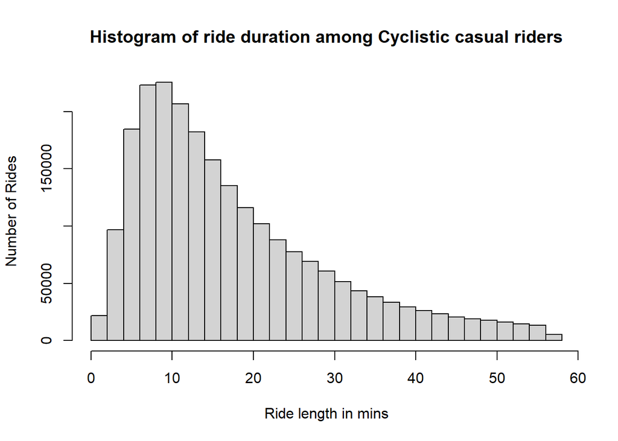

```r
# extract ride duration for only casual
casual_ride_duration <-
  (all_trips %>% filter(rider_type == "casual"))[, "ride_duration"]

# change the data type to numeric
casual_ride_duration$ride_duration <-
  casual_ride_duration$ride_duration %>% as.numeric()

# don't include outliers
casual_ride_duration <-
  casual_ride_duration$ride_duration[!casual_ride_duration$ride_duration %in% boxplot.stats(casual_ride_duration$ride_duration)$out]

# plot histogram to see distribution of ride duration among casual riders
hist(
  casual_ride_duration,
  ,
  xlab = 'Ride length in mins',
  ylab = "Number of Rides",
  main = 'Histogram of ride duration among Cyclistic casual riders'
)
```

```r
#  descriptive statistics of daily average rides for each months
avg_month_ride <-
  all_trips %>% group_by(rider_type, date) %>% summarise(total_ride = n()) %>% group_by(rider_type, month = lubridate::floor_date(date, 'month')) %>% summarise(avg_ride = mean(total_ride, na.rm =
                                                                                                                                                                                  TRUE)) %>% arrange(month)
```

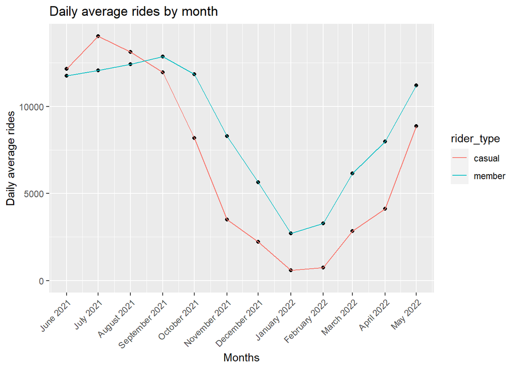

```r
# Visualize daily average rides for Cyclistic members and casual riders at a given month
ggplot(avg_month_ride, aes(x = month, y = avg_ride)) + geom_point() + geom_line(aes(group =
                                                                                      rider_type, colour = rider_type)) + theme(axis.text.x = element_text(angle =
                                                                                                                                                             45, hjust = 1)) + ylim(0, NA) + ggtitle("Daily average rides by month") + labs(x = "Months", y = "Daily average rides") + scale_x_date(date_breaks =
                                                                                                                                                                                                                                                                                                      "1 month", date_labels = "%B %Y")
```

```r
#  descriptive statistics of daily average rides for each day
avg_day_ride <-
  all_trips %>% group_by(rider_type, date, day_of_week) %>% summarise(total_ride = n()) %>% group_by(rider_type, day_of_week) %>% summarise(avg_ride = mean(total_ride, na.rm =
                                                                                                                                                              TRUE)) %>% arrange(day_of_week)
```

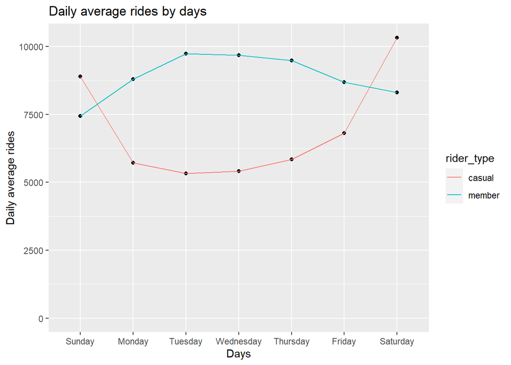

```r
# Visualize daily average rides for Cyclistic members and casual riders at a given day of week
ggplot(avg_day_ride, aes(x = day_of_week, y = avg_ride)) + geom_point() + geom_line(aes(group =
                                                                                          rider_type, colour = rider_type)) + ylim(0, NA) + ggtitle("Daily average rides by days") + labs(x = "Days", y = "Daily average rides")
```

```r
#  descriptive statistics of daily average rides for every hour during weekdays
avg_hour_ride_weekdays <-
  all_trips %>% filter(day_of_week != "Saturday" &
                         day_of_week != "Sunday") %>% group_by(rider_type, date, hour) %>% summarise(total_ride = n()) %>% group_by(rider_type, hour) %>% summarise(avg_ride = mean(total_ride, na.rm =
                                                                                                                                                                                      TRUE)) %>% arrange(hour)
```

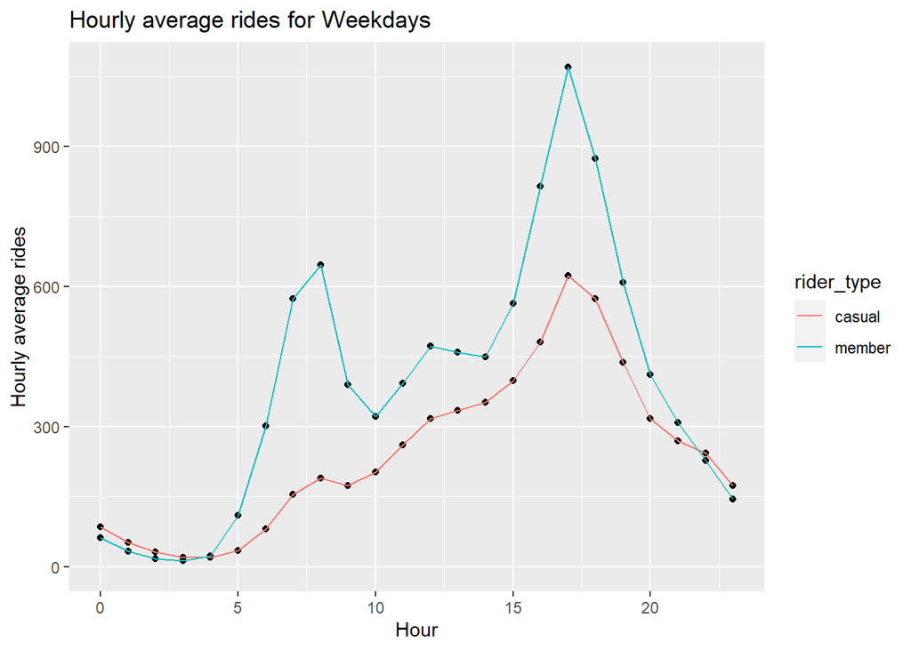

```r
# Visualize hourly average rides for Cyclistic members and casual riders
ggplot(avg_hour_ride_weekdays, aes(x = hour, y = avg_ride)) + geom_point() + geom_line(aes(group =
                                                                                             rider_type, colour = rider_type)) + ylim(0, NA) + ggtitle("Hourly average rides for Weekdays") + labs(x = "Hour", y = "Hourly average rides")
```

```r
#  descriptive statistics of daily average rides for every hour during weekend
avg_hour_ride_weekend <-
  all_trips %>% filter(day_of_week == "Saturday" |
                         day_of_week == "Sunday") %>% group_by(rider_type, date, hour) %>% summarise(total_ride = n()) %>% group_by(rider_type, hour) %>% summarise(avg_ride = mean(total_ride, na.rm =
                                                                                                                                                                                      TRUE)) %>% arrange(hour)
```

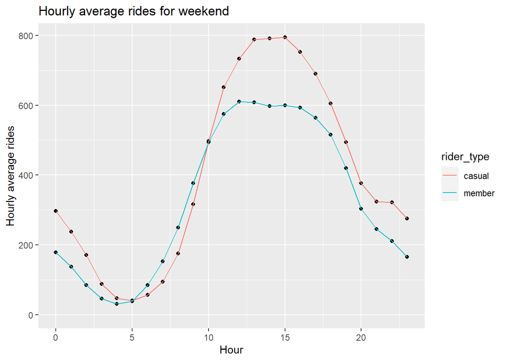

```r
# Visualize hourly average rides for Cyclistic members and casual riders
ggplot(avg_hour_ride_weekend, aes(x = hour, y = avg_ride)) + geom_point() + geom_line(aes(group =
                                                                                            rider_type, colour = rider_type)) + ylim(0, NA) + ggtitle("Hourly average rides for weekend") + labs(x = "Hour", y = "Hourly average rides")
```

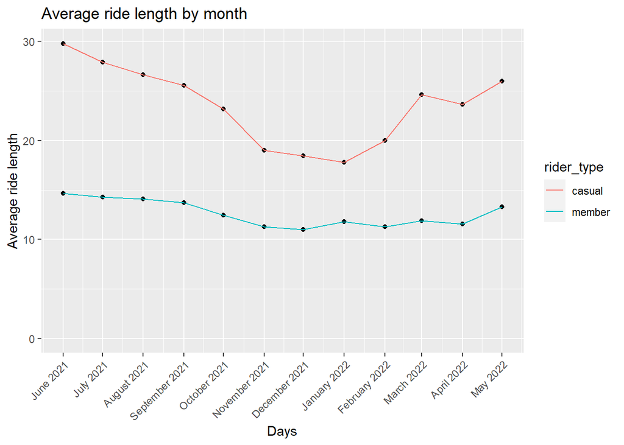

```r
# visualize average ride length by month
all_trips %>% group_by(rider_type, month = lubridate::floor_date(date, 'month')) %>% summarise(avg_ride_duration = mean(ride_duration)) %>% ggplot(aes(x =
                                                                                                                                                         month, y = avg_ride_duration)) + geom_point() + geom_line(aes(group = rider_type, colour = rider_type)) + theme(axis.text.x =
                                                                                                                                                                                                                                                                           element_text(angle = 45, hjust = 1)) + ylim(0, NA) + ggtitle("Average ride length by month") + labs(x = "Days", y = "Average ride length") + scale_x_date(date_breaks =
                                                                                                                                                                                                                                                                                                                                                                                                                                       "1 month", date_labels = "%B %Y")
```

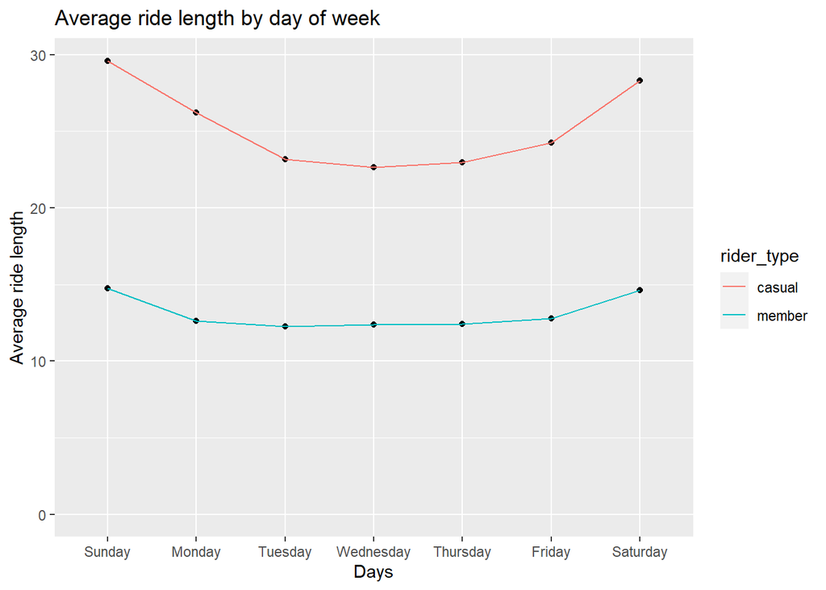

```r
# visualize average ride length by days of week
all_trips %>% group_by(rider_type, day_of_week) %>% summarise(avg_ride_duration = mean(ride_duration)) %>% ggplot(aes(x =
                                                                                                                        day_of_week, y = avg_ride_duration)) + geom_point() + geom_line(aes(group =
                                                                                                                                                                                              rider_type, colour = rider_type)) + ylim(0, NA) + ggtitle("Average ride length by day of week") + labs(x = "Days", y = "Average ride length")
```

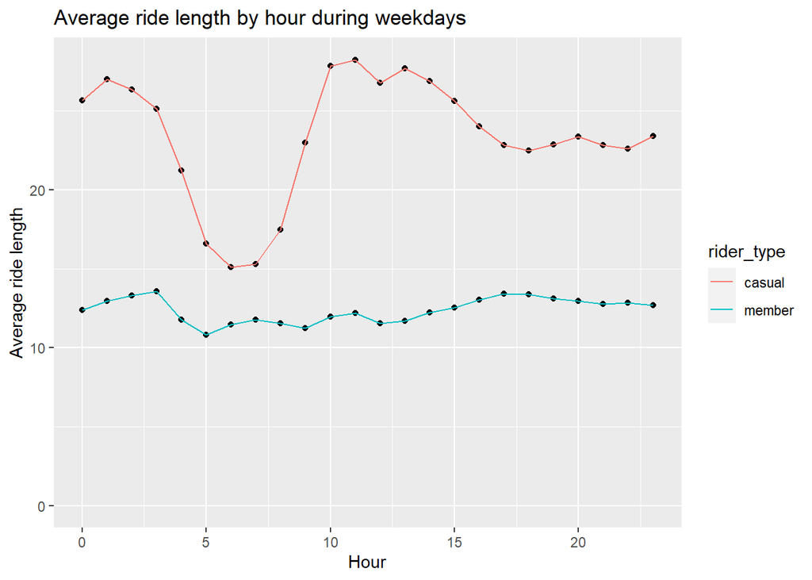

```r
# visulaize average ride length by hour during weekdays
all_trips  %>% filter(day_of_week != "Saturday" &
                        day_of_week != "Sunday") %>% group_by(rider_type, hour) %>% summarise(avg_ride_duration = mean(ride_duration)) %>% ggplot(aes(x =
                                                                                                                                                        hour, y = avg_ride_duration)) + geom_point() + geom_line(aes(group = rider_type, colour = rider_type)) + ylim(0, NA) + ggtitle("Average ride length by hour during weekdays") + labs(x = "Hour", y = "Average ride length")
```

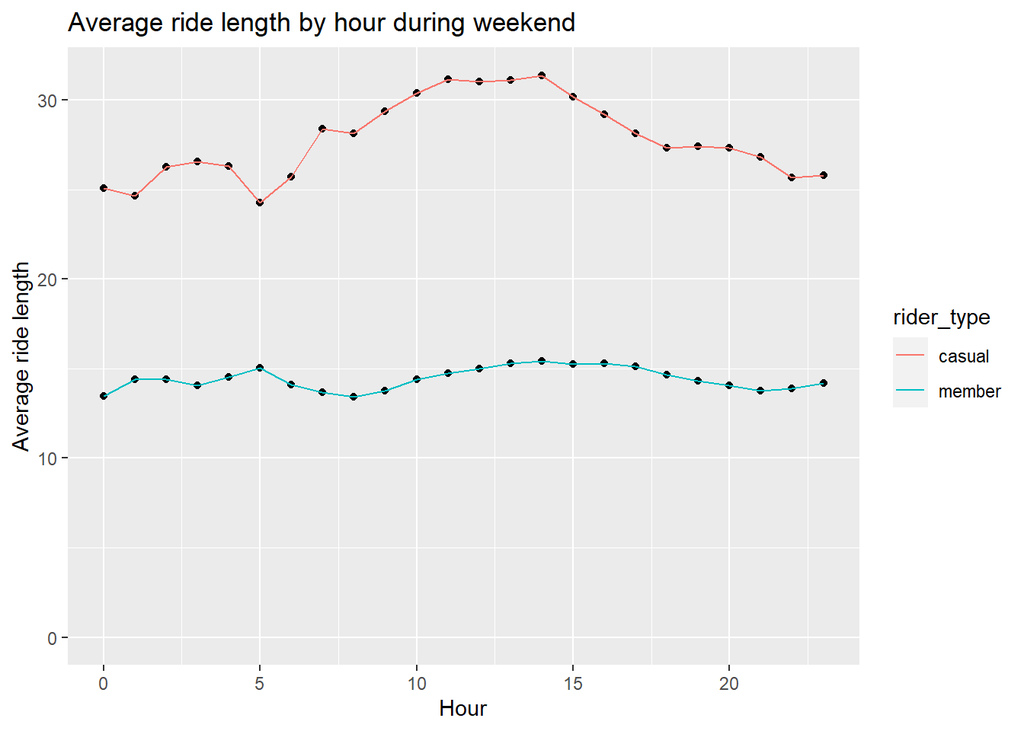

```r
# visulaize average ride length by hour during weekend
all_trips  %>% filter(day_of_week == "Saturday" |
                        day_of_week == "Sunday") %>% group_by(rider_type, hour) %>% summarise(avg_ride_duration = mean(ride_duration)) %>% ggplot(aes(x =
                                                                                                                                                        hour, y = avg_ride_duration)) + geom_point() + geom_line(aes(group = rider_type, colour = rider_type)) + ylim(0, NA) + ggtitle("Average ride length by hour during weekend") + labs(x = "Hour", y = "Average ride length")
```

```r
# calculate daily average rides for each stations
start_station_avg_rides <-
  all_trips %>% filter(start_station_name != " ") %>% group_by(start_station_name, rider_type, date) %>% summarise(num_of_rides = n()) %>% group_by(start_station_name, rider_type) %>% summarise(daily_avg_ride = mean(num_of_rides))

# top 20 stations for member and casual riders
top_20_stations <-
  rbind(
    start_station_avg_rides %>% filter(rider_type == "member") %>% arrange(desc(daily_avg_ride)) %>% head(20),
    start_station_avg_rides %>% filter(rider_type == "casual") %>% arrange(desc(daily_avg_ride)) %>% head(20)
  )
```

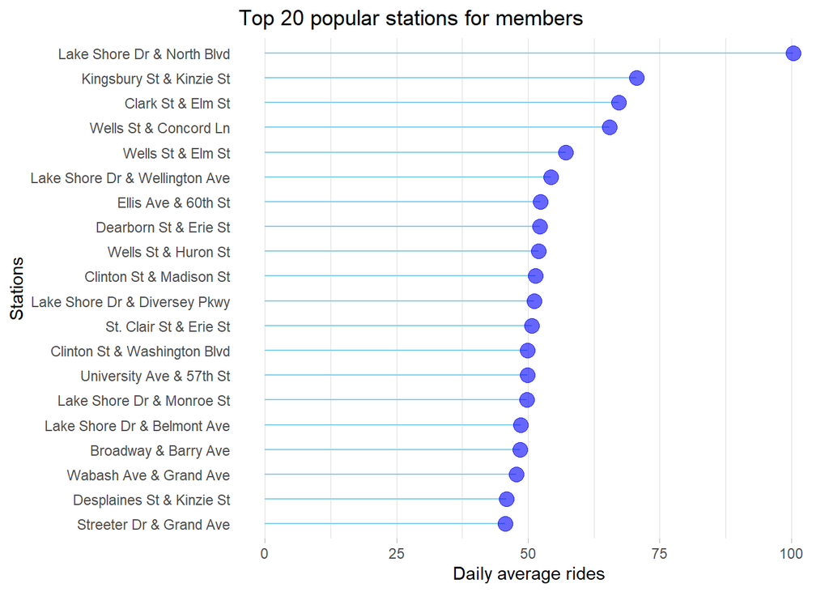

```r
# visualise top 20 stations for members
top_20_stations %>% filter(rider_type == "member") %>% ggplot(aes(x = start_station_name, y =
                                                                    daily_avg_ride)) +
  geom_segment(aes(
    x = reorder(start_station_name, daily_avg_ride),
    xend = reorder(start_station_name, daily_avg_ride),
    y = 0,
    yend = daily_avg_ride
  ),
  color = "skyblue") +
  geom_point(color = "blue",
             size = 4,
             alpha = 0.6) +
  theme_light() +
  coord_flip() +
  theme(
    panel.grid.major.y = element_blank(),
    panel.border = element_blank(),
    axis.ticks.y = element_blank()
  ) + ggtitle("Top 20 popular stations for members") + labs(x = "Stations", y = "Daily average rides")
```

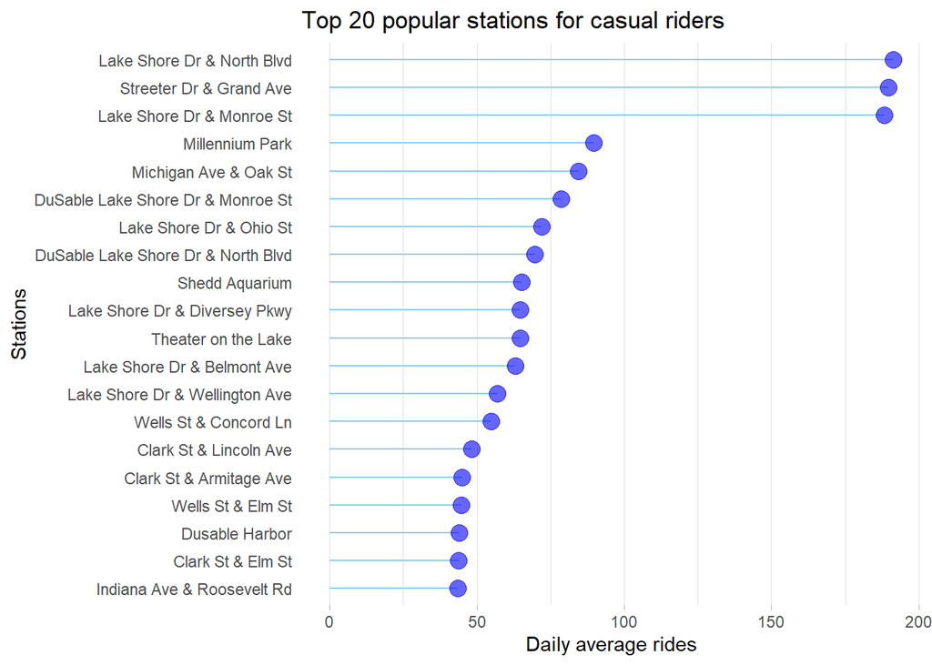

```r
# visualise top 20 stations for casual riders
top_20_stations %>% filter(rider_type == "casual") %>% ggplot(aes(x = start_station_name, y =
                                                                    daily_avg_ride)) +
  geom_segment(aes(
    x = reorder(start_station_name, daily_avg_ride),
    xend = reorder(start_station_name, daily_avg_ride),
    y = 0,
    yend = daily_avg_ride
  ),
  color = "skyblue") +
  geom_point(color = "blue",
             size = 4,
             alpha = 0.6) +
  theme_light() +
  coord_flip() +
  theme(
    panel.grid.major.y = element_blank(),
    panel.border = element_blank(),
    axis.ticks.y = element_blank()
  ) + ggtitle("Top 20 popular stations for casual riders") + labs(x = "Stations", y = "Daily average rides")
```

```r
# create a dataframe with all distinct station names and it's location co-ordinates
distinct_start_stations <-
  all_trips %>% filter(start_station_name != " ") %>% group_by(start_station_name) %>% summarise(lat = mean(start_lat), long = mean(start_lng))
```

```r
# sort the stations, merge with station co-ordinates

top_20_stations <-
  top_20_stations %>% left_join(distinct_start_stations, by = "start_station_name")
```

```r
# visualise top 20 stations for both member and casual riders in map
mytext <- paste(
  "Station name: ",
  top_20_stations$start_station_name,
  "<br/>",
  "Daily Average Ride: ",
  round(top_20_stations$daily_avg_ride, 0),
  sep = ""
) %>%
  lapply(htmltools::HTML)

pal <- colorFactor(c("red", "blue"), domain = c("member", "casual"))
plot <-
  leaflet(top_20_stations) %>% addTiles() %>% addCircleMarkers(
    ~ long,
    ~ lat,
    color = ~ pal(rider_type),
    stroke = FALSE,
    fillOpacity = 0.5,
    label = mytext,
    group = "circles"
  ) %>% addLegend(
    pal = pal,
    values = ~ rider_type,
    group = "circles",
    position = "topright"
  )

plot
```

[interactive chart not shown]

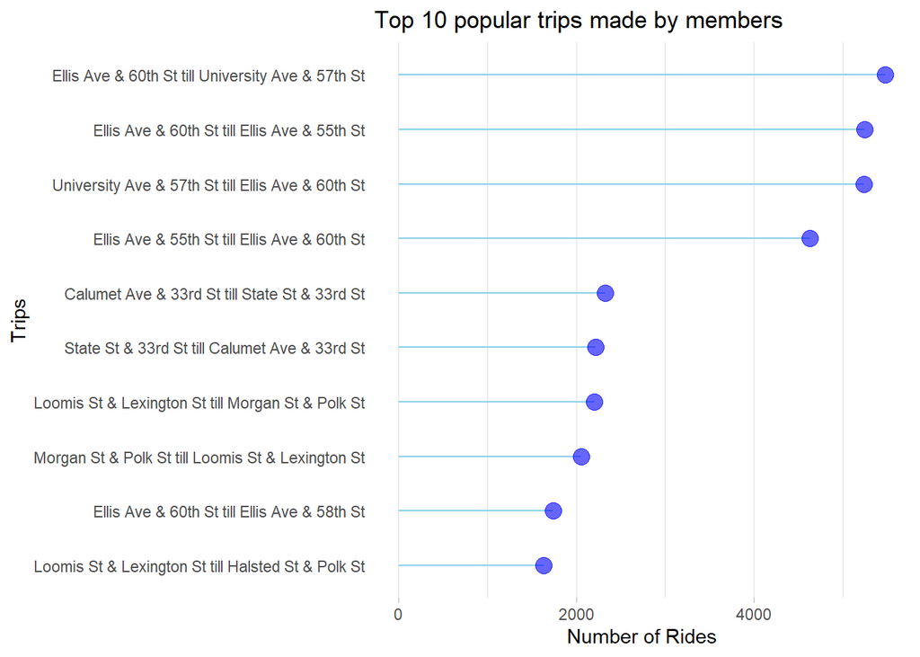

```r
# top 10 trips (from start station till end station) for member
top_trips_member <-
  all_trips %>% filter(start_station_name != " " &
                         end_station_name != " ") %>% mutate(trip = paste(start_station_name, "till", end_station_name)) %>%  group_by(trip, rider_type) %>% summarise(num_of_rides = n()) %>% arrange(desc(num_of_rides)) %>% filter(rider_type == "member") %>% head(10)

# visulaize top 10 trips for member
ggplot(top_trips_member, aes(x = reorder(trip, num_of_rides), y = num_of_rides)) +
  geom_segment(aes(
    x = reorder(trip, num_of_rides),
    xend = reorder(trip, num_of_rides),
    y = 0,
    yend = num_of_rides
  ), color = "skyblue") +
  geom_point(color = "blue",
             size = 4,
             alpha = 0.6) +
  theme_light() +
  coord_flip() +
  theme(
    panel.grid.major.y = element_blank(),
    panel.border = element_blank(),
    axis.ticks.y = element_blank()
  ) + ggtitle("Top 10 popular trips made by members") + labs(x = "Trips", y = "Number of Rides")
```

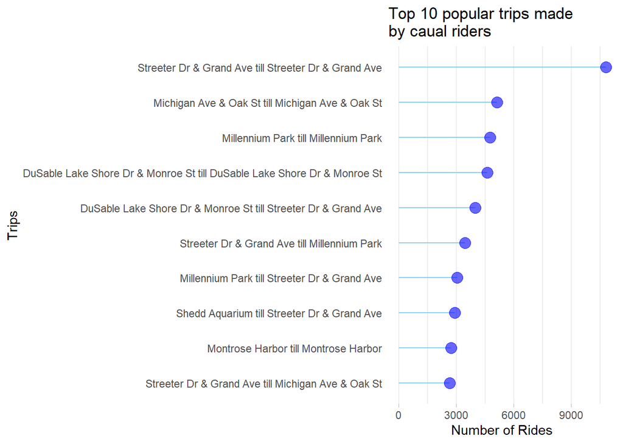

```r
# top 10 trips for casual riders
top_trips_casual <-
  all_trips %>% filter(start_station_name != " " &
                         end_station_name != " ") %>% mutate(trip = paste(start_station_name, "till", end_station_name)) %>%  group_by(trip, rider_type) %>% summarise(num_of_rides = n()) %>% arrange(desc(num_of_rides)) %>% filter(rider_type == "casual") %>% head(10)

# visualize top 10 trips for casual riders
ggplot(top_trips_casual, aes(x = reorder(trip, num_of_rides), y = num_of_rides)) +
  geom_segment(aes(
    x = reorder(trip, num_of_rides),
    xend = reorder(trip, num_of_rides),
    y = 0,
    yend = num_of_rides
  ), color = "skyblue") +
  geom_point(color = "blue",
             size = 4,
             alpha = 0.6) +
  theme_light() +
  coord_flip() +
  theme(
    panel.grid.major.y = element_blank(),
    panel.border = element_blank(),
    axis.ticks.y = element_blank()
  ) + ggtitle(str_wrap("Top 10 popular trips made by caual riders", 25)) + labs(x = "Trips", y = "Number of Rides")
```

## Top 3 Recommendations

For the purpose of this case study, the goal is to help the marketing director design marketing strategies aiming at converting casual riders into annual members. Based on the above analysis and findings, the 3 possible recommendations for the marketing director of Cyclistic are as follows:

1. Offer discounted membership during summer to attract casual riders.
2. Perform customer segmentation, and send push notifications about the membership to customer whose behaviors are similar to members. For an example, casual riders who rides on weekdays to commute.
3. Few popular stations are close to University of Chicago, which could be an indication that the university students are a user of Cyclistic bike-share program. So offering a student discounted membership nearby that area may attract students who are casual riders.